# Machine Learning

Aadrika Singh

## Load all required packages

```r
library(ggplot2)
library(tidyr)
library(caret)
library(car)
library(Hmisc)
library(caTools)
library(forcats)
library(dplyr)
library(lattice)
library(vcd)
library(corrplot)
library(scales)
library(MASS)
library(psych)
library(lsr)
library(DMwR)
library(xgboost)
library(data.table)
library(Matrix)
library(randomForest)
library(plyr)
library(e1071)
library(doParallel)
library(ggthemes)
library(GGally)
library(gridExtra)
```

The purpose of this analysis is to predict the propensity of customers to churn, based on the analysis of other attributes that concern a customer. As the problem aims to predict a binary variable *churn* (<sub>Yes/</sub>No), a classification model should be applied. Since the model will learn from a training set and predict for a test dataset thereafter, it is a supervised model.

Thus, the entire dataset will be split into a training set and a test set (7:3 ratio), such that the distribution of the *churn* variable remains the same as before, for both of the resulting datasets.

```r
# Splitting the dataset into training and test sets
split <- sample.split(telco$churn, SplitRatio = 0.7)
train <- subset(telco, split == TRUE) # TRAIN
test <- subset(telco, split == FALSE) # TEST
```

As was observed from the EDA, the dataset is highly imbalanced. Therefore, we use Synthetic Minority Over-Sampling Technique (SMOTE) to oversample (increase the number of) minority/ under-represented class, and undersample the majority class, so as to strike a balance between the two classes in the training dataset.

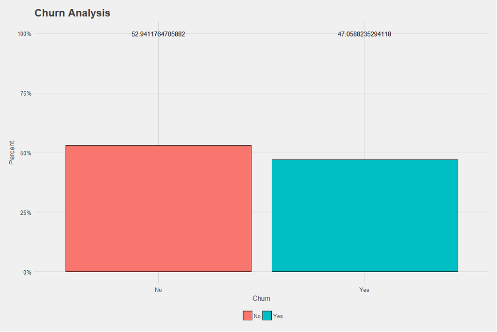

```r
# Synthetic Minority Over - Sampling Technique (SMOTE)
trainDF <- data.table(train, keep.rownames = F)
trainDF <- SMOTE(form = churn ~ ., data = trainDF, perc.over = 300, perc.under = 150)

# Distribution of people who churned in trainDF
ggplot(aes(x = churn, fill = churn), data = trainDF) +
geom_bar(colour = "black", aes(y = ..count../ sum(..count..)), stat = "count") +
ggtitle("Churn Analysis") +
theme_fivethirtyeight() +
xlab('Churn') +
ylab('Percent') +
theme(axis.title=element_text(size=12), legend.title = element_blank()) +
geom_text(aes(label = (..count../ sum(..count..))*100, y= ..prop..), stat= "count") +
scale_y_continuous(labels=percent)
```

The dataset appears to be somewhat balanced after SMOTE, with nearly a 50:50 ratio.

One hot encoding is a process by which each factor for each categorical variable is converted into a binary variable, so that it could be provided to ML algorithms to do a better job in prediction. Thus, one-hot encoding is done on the trainDF dataset.

```r
# One-hot encoding - Create a sparse matrix with categorical variables one-hot encoded
sparse_matrix <- sparse.model.matrix(churn~.-1, data = trainDF)
head(sparse_matrix)
```

```
## 6 x 31453 sparse Matrix of class "dgCMatrix"
```

```
##    [[ suppressing 31 column names 'V1', 'V2', 'V3' ... ]]
```

```
##
## 1  630 . 3.3945740 28   .  19069.200  -31631.56     .  44308   8638 . . .
## 2  287 . 0.4992523 20   . 264797.400   90106.40     .      .      . . . .
## 3  119 . 5.6855370 16   .    763.443   19342.28     .      .      . . . .
## 4 3325 . 4.1971800 82 175  52082.100  103169.20 48897 296212 128905 . . .
## 5  742 . 4.8673360 54  28  51108.300 -268797.60 15651  35020      . . . .
## 6  504 . 1.9709460 52  84   5973.390    4043.84  7002  75504      . . . .
##
## 1 . . . . . . . . . . . . . . . . . . ......
## 2 . . . . . . . . . . . . . . . . . . ......
## 3 . . . . . . . . . . . . . . . . . . ......
## 4 . . . . . . . . . . . . . . . . . . ......
## 5 . . . . . . . . . 1 . . . . . . . . ......
## 6 . . . . . . . . . . . . . . . . . . ......
##
##  .....suppressing columns in show(); maybe adjust 'options(max.print= *, width = *)'
##  ..............................
```

```r
# Create a vector that contains only the rows depicting the customer has churned
output_vector = trainDF[,churn] == "Yes"
```

##### XGBoost Model

XGBoost is an implementation of gradient boosted decision trees designed for speed and performance. Gradient boosting involves three elements:a loss function to be optimized; a weak learner to make predictions, and an additive model to add weak learners to minimize the loss function.

```r
# Create a XGBoost model
XGBmod <- xgboost(data = sparse_matrix, output_vector, nrounds = 10, objective = "binary:logistic")
# Look at feature importance
importance <- xgb.importance(feature_names = colnames(sparse_matrix), model = XGBmod)

# Top 10 important features
head(importance,10)
```

```
##        Feature       Gain       Cover  Frequency
##  1:         V5 0.30449552 0.294820593 0.10714286
##  2:         V4 0.22535941 0.177806899 0.16071429
##  3:        V10 0.13941980 0.143148338 0.12500000
##  4:         V6 0.07620102 0.070712892 0.06071429
##  5:         V2 0.04619060 0.095733545 0.03214286
##  6: V15Unknown 0.04382493 0.068896346 0.02142857
##  7:         V7 0.03690972 0.033087952 0.09285714
##  8:         V9 0.03085262 0.037094276 0.07500000
##  9:         V1 0.03066888 0.020780749 0.06428571
## 10:         V3 0.01470114 0.009182522 0.07500000
```

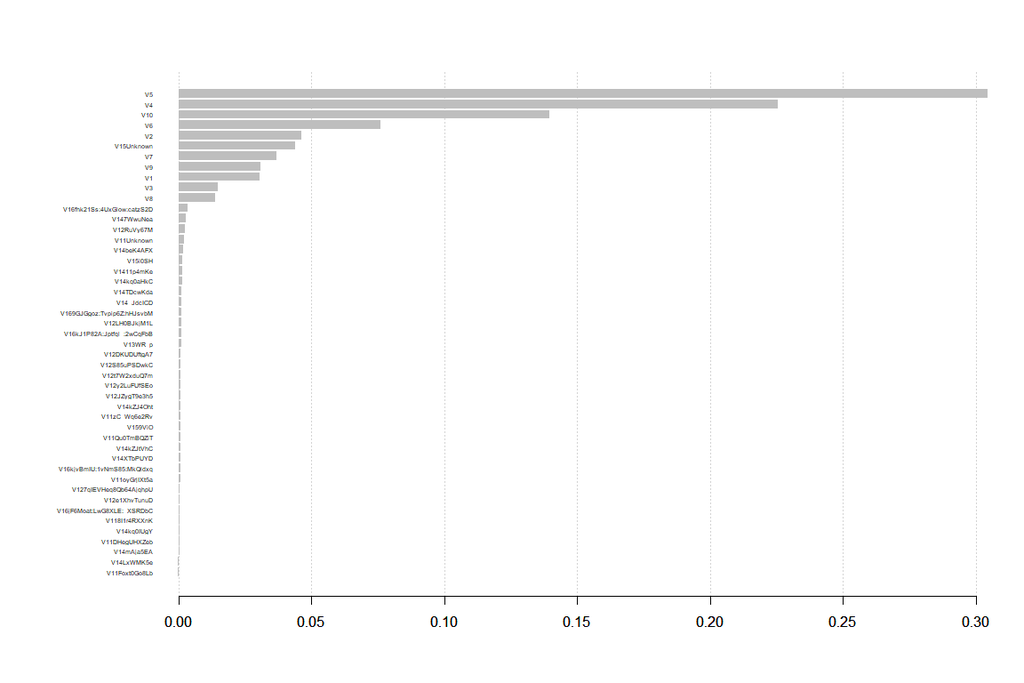

```r
# Plot feature importance plot to see important variables
xgb.plot.importance(importance_matrix = importance)
```

```r
# Prediction on test set and storing the result in a confusion matrix
XGBPredMat <- as.matrix(table(test$churn, as.numeric(predict(XGBmod, xgb.DMatrix(sparse.model.matrix(churn~.-1, data = test))))>0.4))

# Renaming the column and row names
colnames(XGBPredMat) <- c("Will Not Churn", "Will Churn")
rownames(XGBPredMat) <- c("Didn't Churn", "Churned")

# Confusion Matrix
XGBPredMat
```

```
##
##                Will Not Churn Will Churn
##   Didn't Churn           8005       5893
##   Churned                 475        627
```

##### Random Forests

Random forests are ensemble learning method which creates multiple decision trees at the time of traing and outputs the class that is the mode of the classes, for classification models.

```r
########## Random Forest Model 1 ##########

# Since randomForest can't handle categorical predictors with more than 53 categories, we create a dataframe trainRF, which only contains variables upto 53 categorical factor levels
trainRF <- trainDF
for(i in colnames(trainRF)[11:16]){
  if(length(levels(trainRF[[i]])) > 50) {
   trainRF[[i]] <- NULL
   }
}

# Fit the random Forest model using all variables
RFmod <- randomForest(factor(churn)~.,data = trainRF)

# Prediction on test set and storing the result in a confusion matrix
RFPredMat1 <- as.matrix(table(test$churn, predict(object = RFmod, test)))

# Renaming the column and row names
colnames(RFPredMat1) <- c("Will Not Churn", "Will Churn")
rownames(RFPredMat1) <- c("Didn't Churn", "Churned")

# Confusion Matrix
RFPredMat1
```

```
##
##                Will Not Churn Will Churn
##   Didn't Churn          11434       2464
##   Churned                 826        276
```

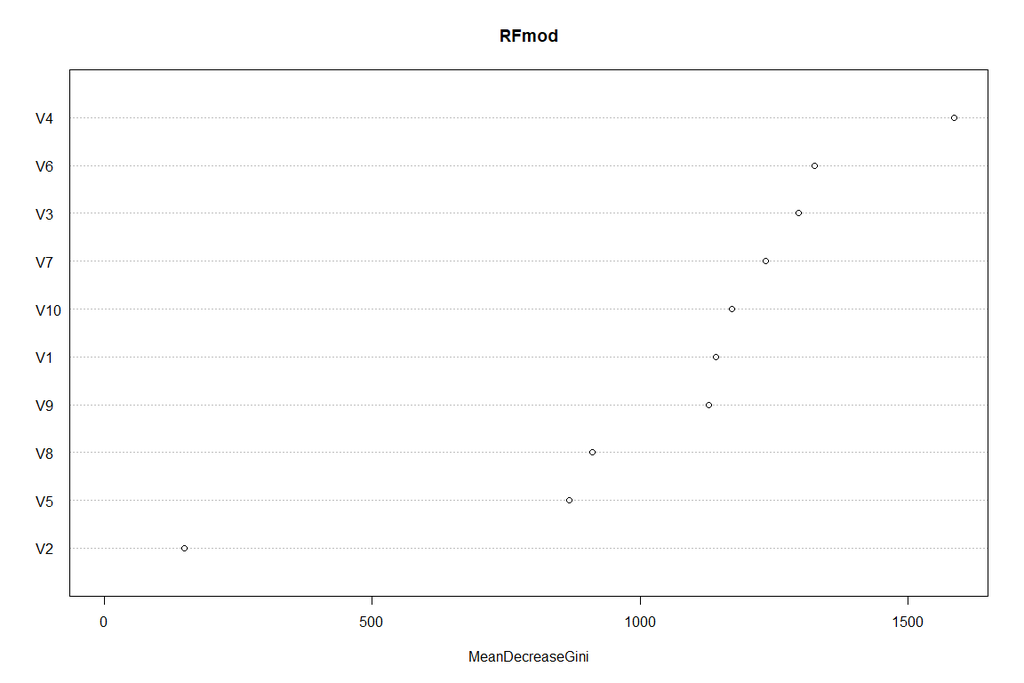

```r
# Use variable importance plot to select top variables
varImpPlot(RFmod)
```

```r
########## Random Forest Model 2 ##########

# Set up parallel computation
cl <- makeCluster(2)
registerDoParallel(cl)

# Specify the type of resampling
fitControl <- trainControl(method = "repeatedcv",
                           number = 5,
                           repeats = 3,
                           summaryFunction = prSummary,
                           classProbs = TRUE,
                           allowParallel = TRUE)

# Set Seed
set.seed(825)

# Fit the random forest model with some of the top variables, as observed from the plot
trainDF <- as.data.frame(trainDF)
rfFit1 <- train(trainDF[,c(4, 6, 3, 7, 10, 1, 9)],
                trainDF[,17],
                data = trainDF,
                method = "rf",
                trControl = fitControl,
                metric = "F"
                )
# RF Model 2
rfFit1
```

```
## Random Forest
##
## 21845 samples
##     7 predictor
##     2 classes: 'No', 'Yes'
##
## No pre-processing
## Resampling: Cross-Validated (5 fold, repeated 3 times)
## Summary of sample sizes: 17476, 17476, 17476, 17476, 17476, 17476, ...
## Resampling results across tuning parameters:
##
##   mtry  AUC        Precision  Recall     F
##   2     0.9062742  0.8234542  0.8251909  0.8242998
##   4     0.9063243  0.8286471  0.8285344  0.8285690
##   7     0.9060137  0.8280644  0.8374982  0.8327230
##
## F was used to select the optimal model using the largest value.
## The final value used for the model was mtry = 7.
```

```r
# Prediction on test set and storing the result in a confusion matrix
RFPredMat2 <- as.matrix(table(test$churn, predict(object = rfFit1, test)))

# Renaming the column and row names
colnames(RFPredMat2) <- c("Will Not Churn", "Will Churn")
rownames(RFPredMat2) <- c("Didn't Churn", "Churned")

# Confusion Matrix
RFPredMat2
```

```
##
##                Will Not Churn Will Churn
##   Didn't Churn          11185       2713
##   Churned                 823        279
```

```r
########## Random Forest Model 3 ##########

# Fit the random forest model with more of the top variables, as observed from the plot
trainDF <- as.data.frame(trainDF)
rfFit2 <- train(trainDF[,c(4, 6, 3, 7, 10, 1, 9, 8, 5)],
                trainDF[,17],
                data = trainDF,
                method = "rf",
                trControl = fitControl,
                metric = "F"
                )

# RF Model 3
rfFit2
```

```
## Random Forest
##
## 21845 samples
##     9 predictor
##     2 classes: 'No', 'Yes'
##
## No pre-processing
## Resampling: Cross-Validated (5 fold, repeated 3 times)
## Summary of sample sizes: 17476, 17476, 17476, 17476, 17476, 17476, ...
## Resampling results across tuning parameters:
##
##   mtry  AUC        Precision  Recall     F
##   2     0.9200923  0.8354231  0.8545612  0.8448650
##   5     0.9182699  0.8387530  0.8514483  0.8450197
##   9     0.9166482  0.8376088  0.8576452  0.8474609
##
## F was used to select the optimal model using the largest value.
## The final value used for the model was mtry = 9.
```

```r
# Prediction on test set and storing the result in a confusion matrix
RFPredMat3 <- as.matrix(table(test$churn, predict(object = rfFit2, test)))

# Renaming the column and row names
colnames(RFPredMat3) <- c("Will Not Churn", "Will Churn")
rownames(RFPredMat3) <- c("Didn't Churn", "Churned")

# Confusion Matrix
RFPredMat3
```

```
##
##                Will Not Churn Will Churn
##   Didn't Churn          11521       2377
##   Churned                 845        257
```

```r
# Stop parallel computation
stopCluster(cl)
registerDoSEQ()
```

## Comparison of the models based on prediction

Metrics to compare models: - Precision (Positive Predictive Value) : Of those classified as *Will churn*, what proportion actually did? - Recall (True Positive Rate) : Of those that in fact Churned, what proportion were classified that way? - Accuracy : Calculated as the number of all correct predictions divided by the total number of the dataset values. - F Score : harmonic mean of precision and recall (so as to balance both accordingly)

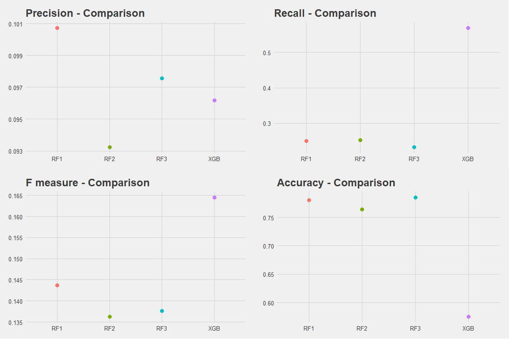

```r
# Evaluate XG Boost Model
P1 <- XGBPredMat[2,2]/(XGBPredMat[1,2] + XGBPredMat[2,2]) # Precision
R1 <- XGBPredMat[2,2]/(XGBPredMat[2,1] + XGBPredMat[2,2]) # Recall
F1 <- (2*P1*R1)/(P1 + R1)                                 # F-measure
A1 <- (XGBPredMat[1,1] + XGBPredMat[2,2])/sum(XGBPredMat) # Accuracy

# Evaluate 1st Random Forest Model
P2 <- RFPredMat1[2,2]/(RFPredMat1[1,2] + RFPredMat1[2,2]) # Precision
R2 <- RFPredMat1[2,2]/(RFPredMat1[2,1] + RFPredMat1[2,2]) # Recall
F2 <- (2*P2*R2)/(P2 + R2)                                 # F-measure
A2 <- (RFPredMat1[1,1] + RFPredMat1[2,2])/sum(RFPredMat1) # Accuracy

# Evaluate 2nd Random Forest Model
P3 <- RFPredMat2[2,2]/(RFPredMat2[1,2] + RFPredMat2[2,2]) # Precision
R3 <- RFPredMat2[2,2]/(RFPredMat2[2,1] + RFPredMat2[2,2]) # Recall
F3 <- (2*P3*R3)/(P3 + R3)                                 # F-measure
A3 <- (RFPredMat2[1,1] + RFPredMat2[2,2])/sum(RFPredMat2) # Accuracy

# Evaluate 3rd Random Forest Model
P4 <- RFPredMat3[2,2]/(RFPredMat3[1,2] + RFPredMat3[2,2]) # Precision
R4 <- RFPredMat3[2,2]/(RFPredMat3[2,1] + RFPredMat3[2,2]) # Recall
F4 <- (2*P4*R4)/(P4 + R4)                                 # F-measure
A4 <- (RFPredMat3[1,1] + RFPredMat3[2,2])/sum(RFPredMat3) # Accuracy

# Create a model evaluation dataframe with all the metrics stored for each model
modelEval <- data.frame(c(P1,P2,P3,P4),c(R1,R2,R3,R4),c(F1,F2,F3,F4),c(A1,A2,A3,A4))

# Column names for the dataframe
colnames(modelEval) <- c("Precision", "Recall", "Fmeasure", "Accuracy")

# Add a column to specify the respective model names for the metrics
modelEval$Model <- as.factor(c("XGB", "RF1", "RF2", "RF3"))

# Rearrange columns
modelEval <- modelEval[,c(5,1:4)]

# Compare Precision of the models
g1 <- ggplot(aes(x = Model, y = Precision, color = Model), data = modelEval) +
  geom_point(size = 3) +
  ggtitle("Precision - Comparison") +
  theme_fivethirtyeight() +
  xlab('Model') +
  ylab('Precision') +
  theme(legend.position = "none")

# Compare Recall of the models
g2 <- ggplot(aes(x = Model, y = Recall, color = Model), data = modelEval) +
  geom_point(size = 3) +
  ggtitle("Recall - Comparison") +
  theme_fivethirtyeight() +
  xlab('Model') +
  ylab('Recall') +
  theme(legend.position = "none")

# Compare F - Measure of the models
g3 <- ggplot(aes(x = Model, y = Fmeasure, color = Model), data = modelEval) +
  geom_point(size = 3) +
  ggtitle("F measure - Comparison") +
  theme_fivethirtyeight() +
  xlab('Model') +
  ylab('F - measure') +
  theme(legend.position = "none")

# Compare Accuracy of the models
g4 <- ggplot(aes(x = Model, y = Accuracy, color = Model), data = modelEval) +
  geom_point(size = 3) +
  ggtitle("Accuracy - Comparison") +
  theme_fivethirtyeight() +
  xlab('Model') +
  ylab('Accuracy') +
  theme(legend.position = "none")

grid.arrange(g1,g2,g3,g4, ncol = 2)
```